# xwOBA_validation

## Validating xwOBA

Last time, I performed some parameter tuning for my gradient boosting model and got set up to finish my hit probability predictions. I did those behind the scenes, and now I'll put them to use. Rather than validating the hit probabilities themselves, I'm going to use them to calculate **xwOBA** and validate that instead.

### Quick Background

One of the most useful stats in baseball today is wOBA, or **weighted on-base average**. It's a rate stat like batting average or slugging percentage, but uses weights that accurately represent the relative value of each type of outcome. Fangraphs has these values tabulated [here](https://www.fangraphs.com/guts.aspx?type=cn). With an out worth 0, a single is worth around 0.88, for example. If I take those weights and use them with my hit probabilities, I can calculate an expected wOBA, or **xwOBA**.

MLB Blogs put out a great post on xwOBA [here](https://technology.mlblogs.com/an-introduction-to-expected-weighted-on-base-average-xwoba-29d6070ba52b). I will note that they chose not to include batted ball spray angle in their model, claiming they haven't found evidence that it contributes significantly to a better or worse outcome. They may well be right -- just to reiterate, I'm including it to see how well outcomes are modeled by all the things a hitter can control. It might turn out that their model outperforms mine, or is better at predicting how a player performs in the future. I'm also going to try to recreate some of their tests, since they should be an excellent baseline.

### Validation and Testing

I'm going to validate my xwOBA estimates using the actual wOBA value of an outcome. First of all, the average xwOBA value of a batted ball should be equivalent to the average wOBA value of a batted ball. I'll also check RMSE between the two. Also, I want to compare the two against some of the contextual clues I left out of my hit probability model, like stadium or defensive talent.

```
/Users/JonahKrop/Documents/Projects/Baseball
```

```python
import pandas as pd
import numpy as np
import seaborn as sns
import matplotlib.pyplot as plt
import matplotlib.tri as tri
import matplotlib.cm as cm
import math
import random
from scipy.interpolate import interp1d

from sklearn.linear_model import LinearRegression
```

```python
# Statcast data with my calibrations
df_2016 = pd.read_csv('mlb_2016_adjusted.csv')
df_2017 = pd.read_csv('mlb_2017_adjusted.csv')
df_2018 = pd.read_csv('mlb_2018_adjusted.csv')
df_2019 = pd.read_csv('mlb_2019_adjusted.csv')

# fangraphs wOBA weights
woba_weights = pd.read_csv('fangraphs_woba_weights.csv')

# my hit probabilities built from only batter contributions
hit_probs = pd.read_csv('true_talent_hit_probability.csv')

df = pd.concat([df_2016, df_2017, df_2018, df_2019], axis=0)

df = df.reset_index(drop=True)

# save some memory
del df_2016
del df_2017
del df_2018
del df_2019
```

### Building xwOBA values

I need to attach Fangraphs' wOBA values to each possible event that can end a plate appearance. I'll filter to those using the `events` column in my dataframe, which is `nan` unless ending a plate appearance. I'm going to eliminate bunts and any event that doesn't involve the batter, like a caught stealing. I'll also convert the long-form outs to a single `out` marker (including errors, since the batter deserves to be out).

I only need a few columns of data:

- pitch_id (unique identifier)
- year
- events (outcome of PA)

I'll throw in some other columns that I'll use for validating the data:

- launch speed
- launch angle
- spray angle
- home team (stadium)
- fielding team
- batter id

```python
df_woba = df.copy(deep=True)
df_woba = df_woba.dropna(subset=['events']).reset_index(drop=True)

# filter to wanted columns
woba_cols = ['pitch_id', 'year', 'events',
             'launch_speed', 'launch_angle', 'direction',
             'home_team', 'fielding_team', 'batter'
             ]
df_woba = df_woba[woba_cols]

# 1) drop bunts and non-batting events
event_drop = ['sac_bunt', 'sac_bunt_double_play',
              'pickoff_1b', 'pickoff_2b', 'pickoff_3b',
              'pickoff_caught_stealing_2b', 'pickoff_caught_stealing_3b', 'pickoff_caught_stealing_home',
              'caught_stealing_2b', 'caught_stealing_3b', 'caught_stealing_home',
              'catcher_interf', 'batter_interference',
              'run',
              'intent_walk'
              ]

df_woba = df_woba[~df_woba['events'].isin(event_drop)]

# 2) any long-version out = out
outs_long = ['field_out', 'force_out', 'other_out', 'field_error',
             'double_play', 'grounded_into_double_play', 'triple_play',
             'strikeout', 'strikeout_double_play',
             'fielders_choice', 'fielders_choice_out',
             'sac_fly', 'sac_fly_double_play'
             ]

df_woba.loc[df_woba['events'].isin(outs_long), 'events'] = 'out'

# verify remaining outcomes
print(list(pd.unique(df_woba['events'])))
```

```
['out', 'single', 'home_run', 'walk', 'double', 'hit_by_pitch', 'triple']
```

Now that I have simplified plate-appearance outcomes, I'll join in Fangraphs' wOBA values for the given season and my hit probabilities for each ball in play.

```python
woba_weights = woba_weights[['Season', 'wBB', 'wHBP', 'w1B', 'w2B', 'w3B', 'wHR']]

df_woba = pd.merge(df_woba, woba_weights, left_on='year', right_on='Season', how='inner')
df_woba = pd.merge(df_woba, hit_probs, on='pitch_id', how='left')

df_woba = df_woba.drop(columns=['Season', 'predicted_event'])

# add marker for ball in play
df_woba['contact'] = np.zeros(len(df_woba))
df_woba.loc[df_woba['prob_out'].notnull()==True, 'contact'] = 1
```

Now I'll write two functions: one for determing the xwOBA value of a PA, and one for determing the wOBA value of a PA.

```python
def calc_xwoba(data):
    '''
    Calculate the xwOBA value for a plate appearance. If PA ends on a ball put in play,
    use hit probabilities to calculate expected wOBA. Else, use known wOBA value.

    '''

    if data['contact'] == 1:
        xwoba = (data['prob_single'] * data['w1B'] + data['prob_double'] * data['w2B'] +
                 data['prob_triple'] * data['w3B'] + data['prob_home_run'] * data['wHR'])

    elif data['events'] == 'walk':
        xwoba = data['wBB']

    elif data['events'] == 'hit_by_pitch':
        xwoba = data['wHBP']

    else:
        xwoba = 0

    return round(xwoba, 3)


def calc_woba(data):
    '''
    Calculate the wOBA value for a plate appearance. Use the known wOBA value for each outcome.

    '''

    if data['events'] == 'single':
        woba = data['w1B']

    elif data['events'] == 'double':
        woba = data['w2B']

    elif data['events'] == 'triple':
        woba = data['w3B']

    elif data['events'] == 'home_run':
        woba = data['wHR']

    elif data['events'] == 'walk':
        woba = data['wBB']

    elif data['events'] == 'hit_by_pitch':
        woba = data['wHBP']

    else:
        woba = 0

    return round(woba, 3)
```

```python
# calculate xwOBA and wOBA for each PA
df_woba['xwoba'] = df_woba.apply(calc_xwoba, axis=1)
df_woba['woba'] = df_woba.apply(calc_woba, axis=1)

# set up xwOBAcon and wOBAcon
df_woba['xwobacon'] = df_woba['xwoba']
df_woba['wobacon'] = df_woba['woba']

# -con is where contact is made
df_woba.loc[df_woba['contact']==0, ['xwobacon', 'wobacon']] = np.nan
```

|  | events | prob_out | prob_single | prob_double | prob_triple | prob_home_run | woba | xwoba | wobacon | xwobacon |
| --- | --- | --- | --- | --- | --- | --- | --- | --- | --- | --- |
| 103207 | double | 0.802 | 0.033 | 0.160 | 0.003 | 0.002 | 1.242 | 0.236 | 1.242 | 0.236 |
| 16480 | out | 0.879 | 0.116 | 0.004 | 0.000 | 0.000 | 0.000 | 0.107 | 0.000 | 0.107 |
| 580164 | walk | NaN | NaN | NaN | NaN | NaN | 0.690 | 0.690 | NaN | NaN |
| 482703 | out | 0.754 | 0.237 | 0.009 | 0.000 | 0.001 | 0.000 | 0.222 | 0.000 | 0.222 |
| 148164 | out | NaN | NaN | NaN | NaN | NaN | 0.000 | 0.000 | NaN | NaN |
| 313537 | single | 0.435 | 0.533 | 0.025 | 0.004 | 0.002 | 0.877 | 0.508 | 0.877 | 0.508 |
| 12083 | single | 0.356 | 0.637 | 0.006 | 0.001 | 0.000 | 0.878 | 0.568 | 0.878 | 0.568 |
| 676102 | double | 0.006 | 0.029 | 0.964 | 0.001 | 0.000 | 1.217 | 1.200 | 1.217 | 1.200 |
| 437617 | out | NaN | NaN | NaN | NaN | NaN | 0.000 | 0.000 | NaN | NaN |
| 463215 | out | NaN | NaN | NaN | NaN | NaN | 0.000 | 0.000 | NaN | NaN |

### wOBA and xwOBA values

Values are all assigned. Above is a random sample of the dataframe just to get an idea of what the actual outcomes, probabilities, and wOBA & xwOBA values are.

Validation time! I'm going to work just with balls in play here, since that's where my hit probabilities are contributing. So, I'll be working with wOBA*con* and xwOBA*con*, since *contact* is made on balls in play.

First of all, I want to make sure that the average xwOBAcon value of a plate appearance matches the average wOBAcon value of a plate appearance.

```
Average wOBAcon value of a PA = 0.371
Average xwOBAcon value of a PA = 0.371
```

Off to a very good start. Next, I'm going to check the RMSE between xwOBAcon and wOBAcon (just on balls in play, since my only contribution here is on balls in play). The MLB Blogs article I linked saw a RMSE around 0.410 with their model, so I'll use that as a benchmark.

```
2016 RMSE = 0.382
2017 RMSE = 0.369
2018 RMSE = 0.377
2019 RMSE = 0.377
```

Nice! So I'm outperforming the 'official' MLB xwOBAcon model in overall RMSE, at least.

## Visualizing xwOBA

I think it will be really helpful to start visualizing how different batted ball profiles contribute to xwOBAcon. I'll do comparisons to wOBAcon here so I can spot any places where the two diverge and try to explain why it happens.

To start, here's a classic heat map of wOBA and xwOBA by launch speed and launch angle. Both show the same underlying pattern -- batted balls at 100+ MPH between around 10$^{\circ}$ - 40$^{\circ}$ are exceptionally successful. In general, these are batted balls that go over the heads of outfielders, which are overwhelmingly hits. Overall, the data matches up. The xwOBAcon plot looks smoother because batted balls have continuous values, whereas with wOBAcon, each outcome has a fixed value.

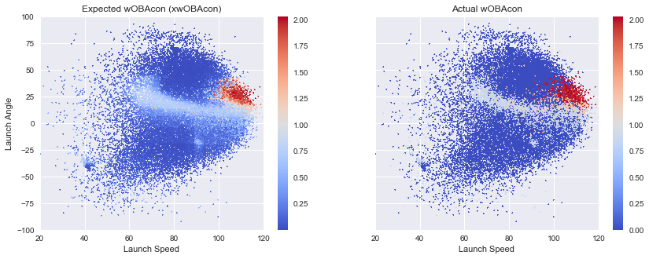

### Effects of Stadiums

Next, I want to check how stadiums affect xwOBAcon vs. wOBAcon. I have some pre-existing knowledge about some stadiums that should come out comparing xwOBAcon and wOBAcon. For example, Yankee Stadium has a famously shallow right field wall. I would expect balls hit to right field there to have a higher wOBAcon value than xwOBAcon value, since the shallow fence creates home runs out of balls that would otherwise not be home runs.

To start, I'll check the RMSE between xwOBAcon and wOBAcon for each stadium. Stadiums with unusual dimensions should stick out here.

Not all batted ball types are going to be affected by this -- ground balls, for example, pretty much never interact with stadium dimensions. I'm going to filter to balls hit reasonably well and in the air -- say 95+ mph, and between 15 and 45 degrees. That should make it possible to find the effects of stadium dimensions.

|  | home_team | year | rmse |
| --- | --- | --- | --- |
| 28 | COL | 2016 | 0.817113 |
| 74 | NYY | 2018 | 0.766424 |
| 75 | NYY | 2019 | 0.736958 |
| 18 | CHC | 2018 | 0.708724 |
| 60 | MIL | 2016 | 0.706541 |

Above are the top 5 stadium-seasons with the worst error. At least 3 of these stadiums have something interesting compared to other stadiums:

- COL: 2nd largest overall outfield area and extreme altitude
- NYY: shallowest right field wall
- CHC: deepest left and right field corners, notorious for high winds

The Milwaukee has pretty normal stadium dimensions, so I'm not sure what's causing error there. This isn't a perfect method, since it's assuming all the error is due just to the stadium.

Let's check out those stadium-seasons graphically!

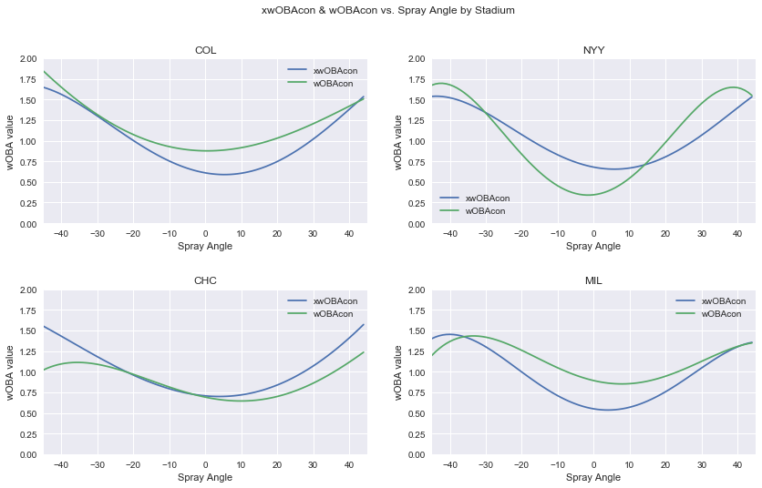

In general, these plots make solid sense:  
1) In Colorado *wOBAcon* is generally higher than *xwOBAcon*, since the high altitude is going to make balls fly further.

2) Balls hit to right field in Yankee Stadium have a higher *wOBAcon* value than *xwOBAcon* value, since it's easier to hit home runs with more poorly struck hits. Not sure what's going on in center field and center-left -- they have pretty standard dimensions out there.

3) Balls hit down the line at Wrigley Field have a higher *xwOBAcon* value, because the deeper fence turns potential home runs into outs or doubles.

4) Not sure why, but there's something in Milwaukee that is creating more positive outcomes than expected. They do have a roofed stadium, but I'm not sure what that would contribute.

I'll check a few other stadiums, just for fun:

- BOS: Green Monster in left, Pesky Pole in right. Weird interplay with massive + shallow fence, very short RF corner that quickly gets very deep
- HOU: shallow fence in left, fairly shallow right field fence
- DET: extremely deep center field fence
- LAD: nothing special, very standard dimensions

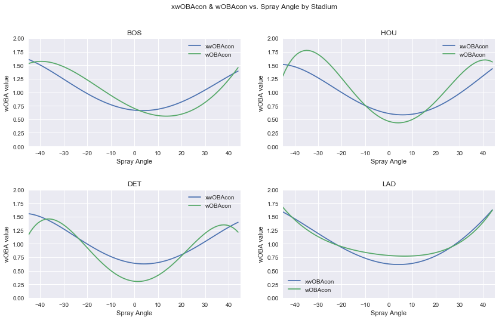

These generally make sense. Dodger Stadium looks pretty even around the field, which makes sense for a stadium with a pretty standard layout. In Houston, we can see the effects of the shallow corner fences, which create positive outcomes more than expected. Detroit shows the opposite -- the extremely deep center field fence makes it really hard to hit home runs.

I wasn't sure what to expect with Boston. The Green Monster is pretty shallow but also extremely tall. It looks like the shallowness is a bigger deal -- the Green Monster ultimately creates more value than it takes away. The deep right field fence wins out and takes away hits.

### Comparison to Actual xwOBA

For my last validation, I'll compare my xwOBA estimates to the official numbers published on Baseball Savant. I'm filtering to players with at least 100 PA's in a season, since 2016. It's not a perfect join, since I'm joining on player name (not necessarily unique), but it should generally do the trick.

I would expect the wOBA values I calculated to be almost precisely the same as the wOBA values on Baseball Savant -- since I'm using publicly available data, it's possible some pitches or plays get missed, which would give me some slightly different results.

```
Gathering player lookup table. This may take a moment.
```

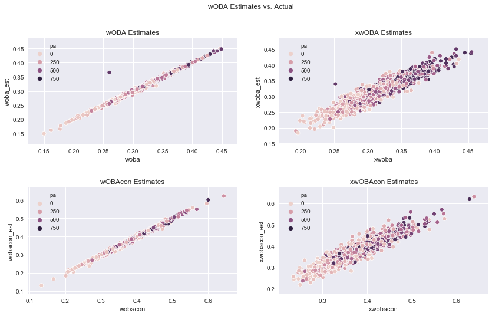

This looks really good to me. The slope of all these lines looks like it's basically 1, and the wOBA estimates line up almost identically with the actual wOBA values. There is one random outlier for wOBA and xwOBA, but it's actually an error (Hanley Ramirez in 2016, Baseball Savant has his wOBA and xwOBA wrong).

At this point I'm pretty comfortable with my results. I'm going to go forward with some analysis -- stuff like looking at predictiveness, maybe some player splits, etc. Some of that should serve as further validation as I check against existing popular data.

Here's my results for the top 20 offensive seasons from the last 4 years, by xwOBA (min 100 PA's).

|  | name | year | pa | woba_est | xwoba_est |
| --- | --- | --- | --- | --- | --- |
| 1226 | Betts, Mookie | 2018 | 605 | 0.448299 | 0.450724 |
| 809 | Trout, Mike | 2019 | 577 | 0.442081 | 0.441669 |
| 1548 | Hoskins, Rhys | 2017 | 211 | 0.417270 | 0.439844 |
| 1046 | Judge, Aaron | 2017 | 667 | 0.430228 | 0.439757 |
| 31 | Cabrera, Miguel | 2016 | 652 | 0.403118 | 0.436810 |
| 807 | Trout, Mike | 2017 | 491 | 0.436426 | 0.435953 |
| 808 | Trout, Mike | 2018 | 582 | 0.446699 | 0.429811 |
| 584 | Freeman, Freddie | 2017 | 495 | 0.407855 | 0.429701 |
| 926 | Muncy, Max | 2018 | 467 | 0.409315 | 0.425208 |
| 0 | Ortiz, David | 2016 | 606 | 0.421172 | 0.424807 |
| 316 | Votto, Joey | 2017 | 686 | 0.427617 | 0.424669 |
| 630 | Stanton, Giancarlo | 2017 | 678 | 0.411106 | 0.420468 |
| 761 | Rendon, Anthony | 2019 | 642 | 0.411220 | 0.419497 |
| 477 | Martinez, Jose | 2017 | 303 | 0.380165 | 0.418769 |
| 525 | Goldschmidt, Paul | 2017 | 648 | 0.401105 | 0.418694 |
| 449 | Recker, Anthony | 2016 | 108 | 0.360583 | 0.418676 |
| 821 | Harper, Bryce | 2017 | 476 | 0.414258 | 0.414721 |
| 132 | Cruz, Nelson | 2017 | 638 | 0.384972 | 0.413423 |
| 615 | Rizzo, Anthony | 2017 | 677 | 0.381514 | 0.411517 |
| 760 | Rendon, Anthony | 2018 | 592 | 0.382953 | 0.408703 |